# hysue_write_up

As we have got a nice cleaned dataset, we want to visualize our data with pair plots first. As shown in the pair plots for the systolic blood pressure, specifically from the scatter plots, we can find that there are weak relations or almost no relations between the variables. Moreover, from the histograms, we can find that the all the variables seem not to be normally distributed. Athough the variable systolic blood pressure and the variable bmi approach to be normally distributed, they are still right skewed. In addition, as shown in the pair plots for the diatolic blood pressure, from the scatter plots, again, we can find that there are weak relations or almost no relations between the variables. Also, from the histograms, except that the variable diatolic blood pressure seems to be almost normally distributed (only a little bit left skewed), all the other variables are not normally distributed.

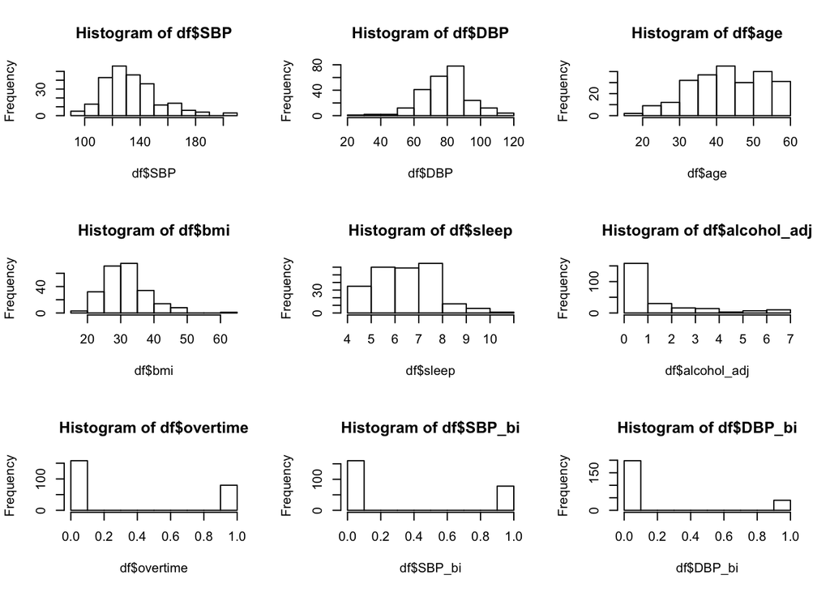

```r
#test the assumptions for the linear regression
#assumption1) normality assumption: check if the continuous variables are normal
par( mfrow=c(3,3) )
#DVs
hist(df$SBP)
hist(df$DBP)
#IVs
hist(df$age)
hist(df$bmi)
hist(df$sleep)
hist(df$alcohol_adj)

#check the distributions
hist(df$overtime)
hist(df$SBP_bi)
hist(df$DBP_bi)
```

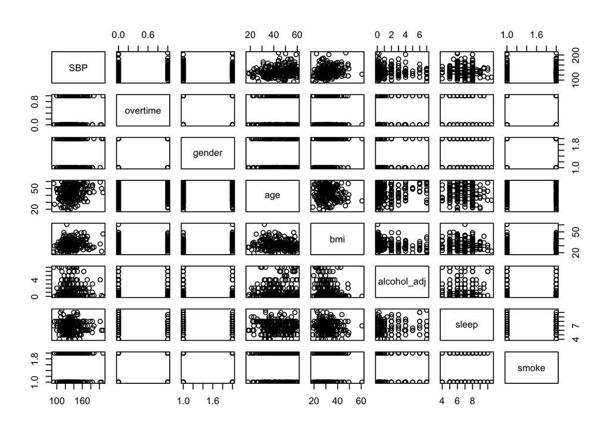

```r
#for SPB
pairs(SBP ~ overtime + gender + age + bmi +
        alcohol_adj + sleep + smoke, data = df)
```

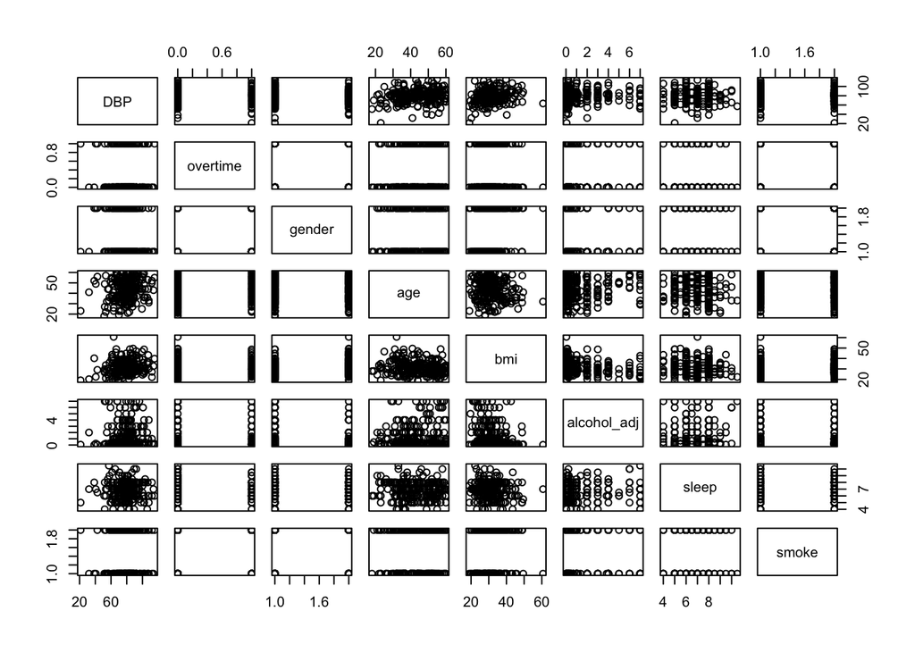

```r
#for DBP
pairs(DBP ~ overtime + gender + age + bmi +
        alcohol_adj + sleep + smoke, data = df)
```

We want to check whether the following assumptions of the linear regression model are held:

1. Homoscedasticity: The variance of the residual is constant. 2. Linearity: The relationship between between the independent and dependent variables is linear. 3. No or little multicollinearity: There is no or little collinearity between independent variables.

1. Linearity

In order to check the linearity assumption, we plotted partial regression plots for both systolic blood pressure and diatolic pressure against each of the independent variables.

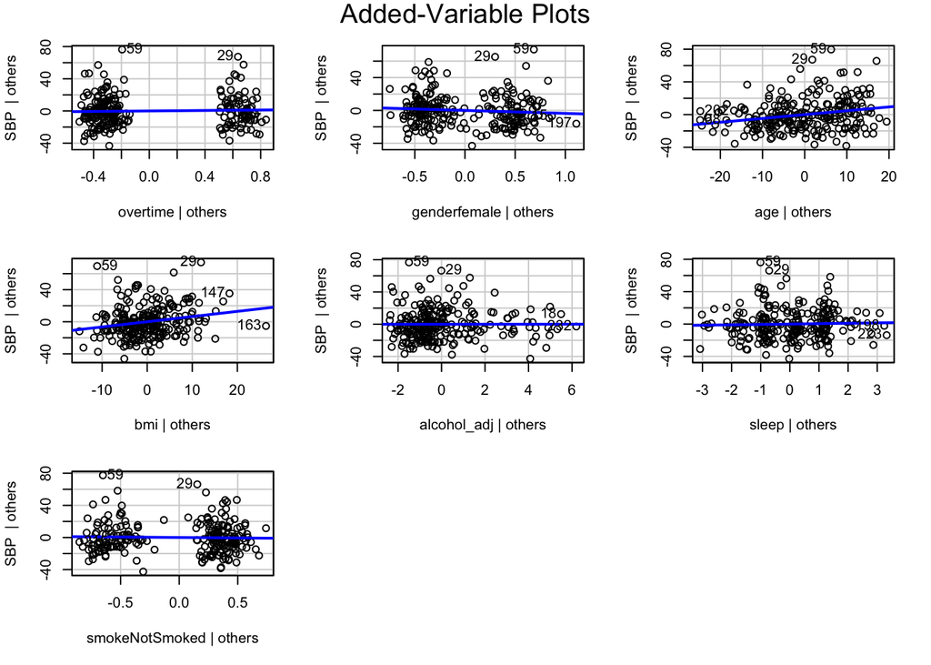

```r
#assumption3) linearity
#first fit a linear regression with all covariates
avplot_SBP = lm(SBP ~ overtime + gender + age + bmi +
                  alcohol_adj + sleep + smoke, data = df)
avplot_DBP = lm(DBP ~ overtime + gender + age + bmi +
                  alcohol_adj + sleep + smoke, data = df)
#then see the added variable plots
car::avPlots(avplot_SBP) #for SBP
```

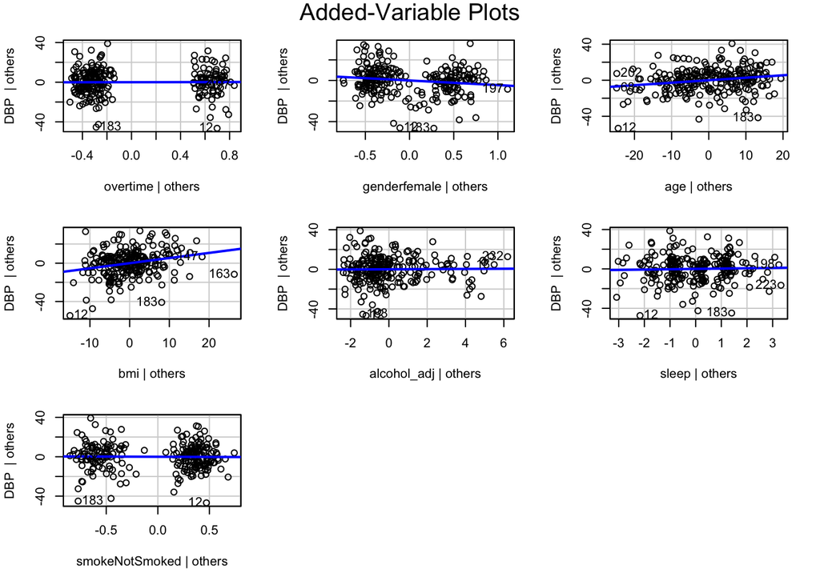

```r
car::avPlots(avplot_DBP) #for DBP
```

From the partial regression plots of the systolic blood pressure, we can find that for each of the independent variable, the expected value of the dependent variable (systolic blood pressure) is indeed a straight-line function of the independent variable, holding the others fixed. Also, from the partial regression plots of the diatolic blood pressurewe, we can get the same conclusion. Therefore, the assumption of linearity can be considered as satisfied.

2. Homoscedasticity

In order to check the homoscedasticity assumption, we plotted residual plots for both systolic blood pressure and diatolic pressure.

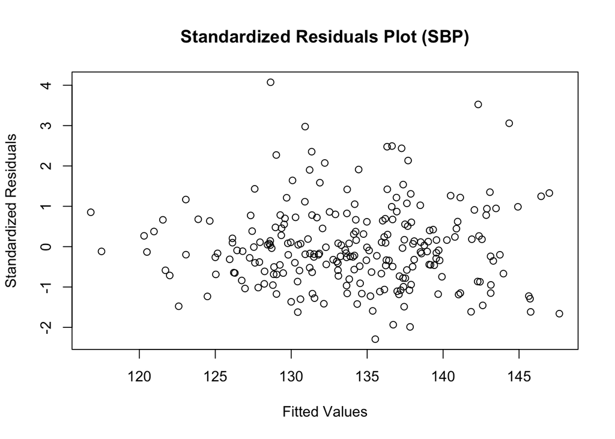

```r
#standardized residuals plot
#SBP
SBP_red = rstandard(avplot_SBP)
fitted_SBP = avplot_SBP$fitted.values

plot(fitted_SBP, SBP_red, xlab = "Fitted Values",
     ylab = "Standardized Residuals",
     main = "Standardized Residuals Plot (SBP)")
```

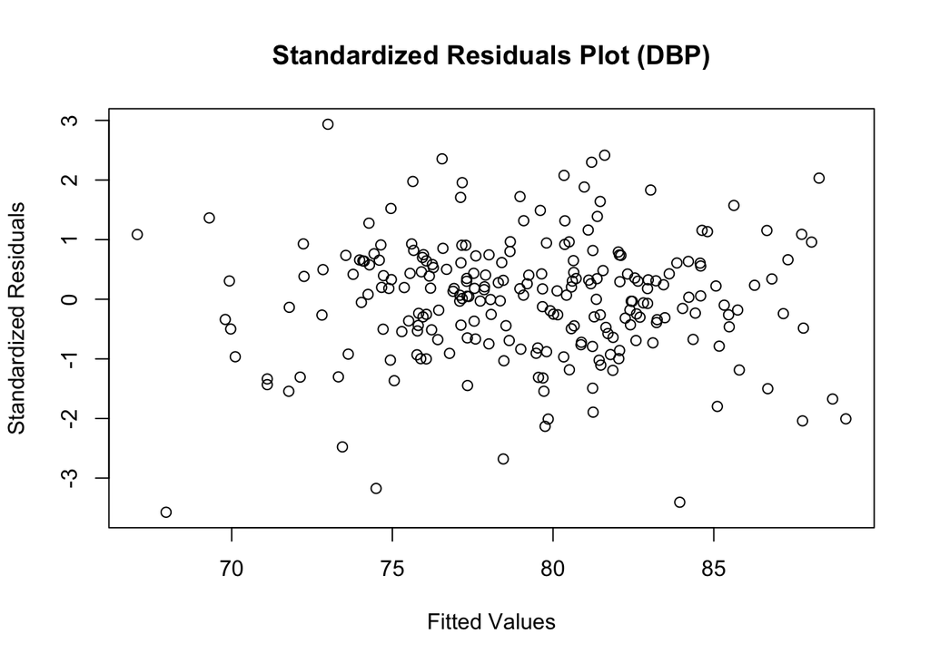

```r
#DBP
DBP_red = rstandard(avplot_DBP)
fitted_DBP = avplot_DBP$fitted.values

plot(fitted_DBP, DBP_red, xlab = "Fitted Values",
     ylab = "Standardized Residuals",
     main = "Standardized Residuals Plot (DBP)")
```

From the residual plot of the systolic blood pressure, we can find the mean of the residual is almost 0, and the variance seems to be almost constant. Also, we have the same finds for the diatolic blood pressure. Therefore, the assumption of homoscedasticity can be considered as satisfied.

2. No or little multicollinearity

In order to check the no/little-multicollinearity assumption, we computed the Pearson correlations between the continuous independent variables and Chi-squared correlation test between the binary independent variables.

```r
#collinearity for continuous variables
cont_df = df %>%
  select(age, bmi, alcohol_adj, sleep)
cor(cont_df)
```

```
##                     age         bmi alcohol_adj       sleep
## age          1.00000000 -0.13615718  0.11946370 -0.02952827
## bmi         -0.13615718  1.00000000 -0.21568224 -0.08195345
## alcohol_adj  0.11946370 -0.21568224  1.00000000  0.04966028
## sleep       -0.02952827 -0.08195345  0.04966028  1.00000000
```

```r
#correlation coefficients have small values
```

```r
#collinearity for categorical variables
cate_df = df %>%
  select(gender, smoke, overtime)
chisq.test(cate_df$gender, cate_df$smoke)
```

```
##
##  Pearson's Chi-squared test with Yates' continuity correction
##
## data:  cate_df$gender and cate_df$smoke
## X-squared = 3.1535, df = 1, p-value = 0.07577
```

```r
chisq.test(cate_df$gender, cate_df$overtime)
```

```
##
##  Pearson's Chi-squared test with Yates' continuity correction
##
## data:  cate_df$gender and cate_df$overtime
## X-squared = 1.1059, df = 1, p-value = 0.293
```

```r
chisq.test(cate_df$smoke, cate_df$overtime)
```

```
##
##  Pearson's Chi-squared test with Yates' continuity correction
##
## data:  cate_df$smoke and cate_df$overtime
## X-squared = 2.9287, df = 1, p-value = 0.08702
```

```r
#no significant associations
```

We fit our linear regression models.

For the systolic blood pressure, we fit the model:

$$\begin{aligned}
y &= \beta_{0} + \beta_{workhrs}*x_{workhrs} + \beta_{gender}*x_{gender} + \beta_{age}*x_{age} + \beta_{bmi}*x_{bmi} \notag\\
&+ \beta_{sleep}*x_{sleep} + \beta_{smoke}*x_{smoke} + \beta_{avg\_alcohol\_freq\_wk}*x_{avg\_alcohol\_freq\_wk} + \epsilon
\end{aligned}$$

And for diatolic blood pressure, we fit the model:
$$\begin{aligned}
y &= \beta_{0} + \beta_{workhrs}*x_{workhrs} + \beta_{gender}*x_{gender} + \beta_{age}*x_{age} + \beta_{bmi}*x_{bmi} \notag\\
&+ \beta_{sleep}*x_{sleep} + \beta_{smoke}*x_{smoke} + \beta_{avg\_alcohol\_freq\_wk}*x_{avg\_alcohol\_freq\_wk} + \epsilon
\end{aligned}$$

```r
#core analysis ----------------------------------------------
#linear regression with "overtime" as the main predictor
model_SBP = gls(SBP ~ overtime + gender + age + bmi +
                  alcohol_adj + sleep + smoke, data = df)
summary(model_SBP)
```

```
## Generalized least squares fit by REML
##   Model: SBP ~ overtime + gender + age + bmi + alcohol_adj + sleep + smoke
##   Data: df
##        AIC      BIC    logLik
##   2079.396 2110.338 -1030.698
##
## Coefficients:
##                   Value Std.Error   t-value p-value
## (Intercept)    91.48710 11.615224  7.876482  0.0000
## overtime        1.57529  2.676871  0.588481  0.5568
## genderfemale   -3.62499  2.743774 -1.321168  0.1878
## age             0.47042  0.127233  3.697308  0.0003
## bmi             0.64715  0.202476  3.196195  0.0016
## alcohol_adj     0.01917  0.719598  0.026644  0.9788
## sleep           0.49186  0.980048  0.501874  0.6162
## smokeNotSmoked -1.19423  2.650964 -0.450489  0.6528
##
##  Correlation:
##                (Intr) overtm gndrfm age    bmi    alchl_ sleep
## overtime        0.005
## genderfemale    0.102  0.107
## age            -0.544 -0.071 -0.063
## bmi            -0.652 -0.040 -0.238  0.137
## alcohol_adj    -0.101  0.029  0.239 -0.130  0.113
## sleep          -0.637 -0.042 -0.104  0.058  0.103 -0.068
## smokeNotSmoked -0.033 -0.113 -0.059 -0.123 -0.055  0.180 -0.031
##
## Standardized residuals:
##        Min         Q1        Med         Q3        Max
## -2.2317121 -0.6388468 -0.1245573  0.5466566  3.9927520
##
## Residual standard error: 19.20794
## Degrees of freedom: 238 total; 230 residual
```

```r
model_DBP = gls(DBP ~ overtime + gender + age + bmi +
                  alcohol_adj + sleep + smoke, data = df)
summary(model_DBP)
```

```
## Generalized least squares fit by REML
##   Model: DBP ~ overtime + gender + age + bmi + alcohol_adj + sleep + smoke
##   Data: df
##        AIC      BIC    logLik
##   1919.121 1950.063 -950.5603
##
## Coefficients:
##                   Value Std.Error   t-value p-value
## (Intercept)    49.75757  8.198020  6.069462  0.0000
## overtime        0.22461  1.889335  0.118884  0.9055
## genderfemale   -4.50410  1.936555 -2.325832  0.0209
## age             0.27600  0.089801  3.073463  0.0024
## bmi             0.53780  0.142907  3.763260  0.0002
## alcohol_adj     0.09092  0.507892  0.179023  0.8581
## sleep           0.33936  0.691717  0.490607  0.6242
## smokeNotSmoked -0.34427  1.871050 -0.183997  0.8542
##
##  Correlation:
##                (Intr) overtm gndrfm age    bmi    alchl_ sleep
## overtime        0.005
## genderfemale    0.102  0.107
## age            -0.544 -0.071 -0.063
## bmi            -0.652 -0.040 -0.238  0.137
## alcohol_adj    -0.101  0.029  0.239 -0.130  0.113
## sleep          -0.637 -0.042 -0.104  0.058  0.103 -0.068
## smokeNotSmoked -0.033 -0.113 -0.059 -0.123 -0.055  0.180 -0.031
##
## Standardized residuals:
##         Min          Q1         Med          Q3         Max
## -3.43931088 -0.53464833  0.06774935  0.60387772  2.87705186
##
## Residual standard error: 13.55695
## Degrees of freedom: 238 total; 230 residual
```

From the summary results of the linear regression model for the systolic blood pressure, we can find that although the coefficient of the working hours is positive, which implies that working overtime increases the risk of high systolic blood pressure, this effect is not significant ($\beta = 1.58$, p = 0.557). As a result, we can conclude that working overtime cannot lead to abnormal systolic blood pressure. Besides, from the summary results of the linear regression model for the diatolic blood pressure, we can find that although the coefficient of the working hours is positive as well, which implies that working overtime increases the risk of high diatolic blood pressure too, this effect is not significant as well($\beta = 0.2246$, p = 0.905). As a result, we can conclude that working overtime also cannot lead to abnormal diatolic blood pressure. Therefore, in conclusion, working overtime also cannot lead to abnormal blood pressure.

```r
#logistic regression with normal vs. abnormal BP outcome
logistic_SBP <- glm(SBP_bi ~ overtime + gender + age + bmi +
                      alcohol_adj + sleep + smoke,
                    family = binomial(link = 'logit'),
                    data = df)
summary(logistic_SBP)
```

```
##
## Call:
## glm(formula = SBP_bi ~ overtime + gender + age + bmi + alcohol_adj +
##     sleep + smoke, family = binomial(link = "logit"), data = df)
##
## Deviance Residuals:
##     Min       1Q   Median       3Q      Max
## -1.4280  -0.9191  -0.6722   1.1867   2.0208
##
## Coefficients:
##                Estimate Std. Error z value Pr(>|z|)
## (Intercept)    -6.16441    1.47603  -4.176 2.96e-05 ***
## overtime        0.23889    0.30418   0.785 0.432245
## genderfemale   -0.18500    0.31844  -0.581 0.561264
## age             0.05307    0.01587   3.343 0.000828 ***
## bmi             0.06839    0.02381   2.872 0.004075 **
## alcohol_adj     0.06821    0.08061   0.846 0.397494
## sleep           0.12490    0.11583   1.078 0.280894
## smokeNotSmoked -0.08405    0.30729  -0.274 0.784450
## ---
## Signif. codes:  0 '***' 0.001 '**' 0.01 '*' 0.05 '.' 0.1 ' ' 1
##
## (Dispersion parameter for binomial family taken to be 1)
##
##     Null deviance: 301.1  on 237  degrees of freedom
## Residual deviance: 280.7  on 230  degrees of freedom
## AIC: 296.7
##
## Number of Fisher Scoring iterations: 4
```

```r
logistic_DBP <- glm(DBP_bi ~ overtime + gender + age + bmi +
                      alcohol_adj + sleep + smoke,
                    family = binomial(link = 'logit'),
                    data = df)
summary(logistic_DBP)
```

```
##
## Call:
## glm(formula = DBP_bi ~ overtime + gender + age + bmi + alcohol_adj +
##     sleep + smoke, family = binomial(link = "logit"), data = df)
##
## Deviance Residuals:
##     Min       1Q   Median       3Q      Max
## -1.0715  -0.6532  -0.4741  -0.3401   2.3798
##
## Coefficients:
##                Estimate Std. Error z value Pr(>|z|)
## (Intercept)    -6.74815    1.83339  -3.681 0.000233 ***
## overtime        0.41364    0.37478   1.104 0.269727
## genderfemale   -0.62077    0.41894  -1.482 0.138402
## age             0.05215    0.02025   2.576 0.010003 *
## bmi             0.08619    0.02941   2.931 0.003380 **
## alcohol_adj     0.11436    0.09444   1.211 0.225925
## sleep           0.01283    0.14374   0.089 0.928902
## smokeNotSmoked -0.28536    0.38274  -0.746 0.455936
## ---
## Signif. codes:  0 '***' 0.001 '**' 0.01 '*' 0.05 '.' 0.1 ' ' 1
##
## (Dispersion parameter for binomial family taken to be 1)
##
##     Null deviance: 215.54  on 237  degrees of freedom
## Residual deviance: 197.34  on 230  degrees of freedom
## AIC: 213.34
##
## Number of Fisher Scoring iterations: 5
```